# Oogkleurprevalentie onder studenten van de Hanzehogeschool Groningen; Een verkennend onderzoek naar genetische variatie

Willem-Daniël Visser $^1$, Cheyenne Brouwer $^1$, Demi van ’t Oever $^1$, Kasthury Inparajah$^1$ $^1$Hanzehogeschool Groningen

```r
knitr::opts_chunk$set(out.width = '100%', dpi=300) # configuratie voor figuur grootte en resolutie
knitr::opts_chunk$set(echo = FALSE)

library(tidyverse)
library(readxl)
library(plyr)
library(dplyr)
library(knitr)
library(ggplot2)
library(gmodels)
```

# Introductie

De afgelopen decennia is er veel onderzoek gedaan naar genetische variaties tussen populaties, waaronder de haar- en oogkleur. Deze onderzoeken kunnen helpen bij het in kaart brengen van bepaalde fysieke kenmerken in populaties & individuen om bijvoorbeeld de nauwkeurigheid van voorspellingen op basis van DNA te verbeteren.

Het onderzoek op de Hanzehogeschool te Groningen is uitgevoerd om te kijken of er een ‘dominante’ oogkleur op de locatie is en hoe dit tegenover andere locaties in Nederland staat. Onderzoek naar de prevalentie van oogkleuren is belangrijk en relevant om verschillende redenen, waaronder forensisch onderzoek en genetische en medische aspecten.

Uit eerdere onderzoeken is alleen de oogkleurprevalentie van heel Nederland in het algemeen bekend en niet specifiek een regio of gebied. Voor dit onderzoek is er gebruik gemaakt van een protocol dat in de repository op `Github` te vinden is. De ogen van 120 personen, exact verdeeld over 3 locaties (Hanzehogeschool Groningen, het centrum van Groningen en het centrum van Zwolle), zijn door 4 analisten gemeten met behulp van een zelf in elkaar gestelde referentiekaart dat tevens ook in de repository op `Github` is te vinden. De metingen zijn genoteerd in diverse notitie software (Google Docs, Apple en Samsung notities en Keep My Notes). Voor het meten van de oogkleur is er rekening gehouden met verschillende factoren zoals de invloed van zonlicht op het waarnemen van de oogkleur en het dragen van gekleurde contactlenzen.

Het doel van dit onderzoek is om de prevalentie van oogkleuren op de Hanzehogeschool Groningen te onderzoeken. Hierbij worden de oogkleur prevalentie bij 2 andere locaties (het centrum van Groningen en het centrum van Zwolle) ook onderzocht en vergeleken met de oogkleurprevalentie op de Hanzehogeschool Groningen.

Voor dit onderzoek zijn de data uit het onderzoek geanalyseerd met behulp van de statische methode `chi-square` test. Als eerste is er gekeken of er een aantoonbaar verschil zat in de oogkleur tussen mannen en vrouwen door middel van een statistische test (`chi-square` test) uit te voeren. Daarna is er met behulp van de dezelfde `chi-square` test gekeken of de oogkleuren per locatie van elkaar verschillen. Vervolgens is de data uit het eigen onderzoek vergeleken met data uit een ander literatuuronderzoek en ten slotte is er gekeken of er een meetfout door de analisten is gemaakt.

# Materialen en Methoden

De analisten vulden soms twee kleuren in of een kleur karakteristiek, zoals: donker of licht. Op dag 1 is er op de studentencampus, de Hanzehogeschool Groningen; Zerniekeplein 11, binnen in het gebouw “Van Doorenveste” gemeten (Groningen 1). Op dezelfde dag is er in het centrum van Groningen (Groningen 2) gemeten. Op een dag 2 is vervolgens in het centrum van Zwolle (Zwolle) gemeten. Op alle drie locaties was het zonnig weer op het moment van metingen. Ook was het onder schooltijd voor de meeste MBO en HBO studenten. Op locatie Groningen 1 was de licht conditie niet constant met variërende daglicht reflectie, licht temperaturen en licht amplitude. Er waren geen licht condities die de oogkleur bepaling onmogelijk/erg moeilijk heeft gemaakt, aldus de analisten. Op locaties Groningen 2 en Zwolle is niet rechtstreeks richting de zon gekeken bij het bepalen van de oogkleur. Wel is er zowel in zon als schaduw gemeten.

Toen de metingen klaar waren werden alle metingen verzameld door 1 van de analisten en verwerkt zodat de dubbele kleuren door de analisten genoteerd resulteren tot enkele kleuren. De verwerkte data is in tidy vorm gezet met de functie `pivot_longer()`` uit de tidyr package[@ref(tidyr)] in de programmeertaal R[@ref(r-lang)]. Het resultaat is opgeslagen in een nieuw bestand en zijn analyses mee gedaan.

De analyses zijn gedaan in R-studio[@ref(r-studio)] en de programmeertaal R, met de libraries: plyr[@ref(plyr)], dyplyr[@ref(dplyr)], ggplot2[@ref(ggplot2)] en knitr[@ref(knitr)] van de tidyverse collectie. Met `plyr` en `dyplyr` is dataverwerking gedaan, zo kon er analyse worden gedaan op gefilterde delen van de data. Met `ggplot` zijn vervolgens grafieken gemaakt. Voor de analyse van de meetfout tussen de analisten is de functie `chisq.test` van R gebruikt, voor een two-way chi-square test, tussen met de factoren analist en oogkleur, met daarvoor alle gemeten personen met een of meer lege velden weggehaald. De analyse voor de verschillen tussen de drie meet locaties en verschillen tussen sexe is eerst de data zonder meerderheid onder de analisten als “undefined” neergezet, om zo aan te geven dat er geen definitieve oogkleur valt te bepalen. Toen werd de `CrossTable` voor de chi-square test en nog andere statistische waarden gebruikt. Hierbij is de locatie in groepjes gezet op basis van subject id en opgezet tegen de oogkleur. En de sexe ook opgezet tegen de oogkleur. Als analyse voor de vergelijking van de percentages van de gemeten kleuren zijn de deze uitgerekend en vergeleken met die van de literatuur. Voor de verschillen tussen twee metingen te zien in tabellen en grafieken is het laagste meting gedeeld door het hoogste meting en maal 100.

# Resultaten

Om er achter te komen welk oogkleur de Hanzehogeschool Groningen aanleg voor heeft is er eerst gekeken of er een significante meetfout is gevormd. Dit is met behulp van een tabel met het aantal opnamen per analist per oogkleur en een aantal percentages die hieruit gehaald kunnen worden en de p-waarde resulterend van een tweezijdige chi-square test. Zo kunnen kan er worden gekeken welke analisten de grootste verschillen in het aantal opnamen en of het verschil significant is en dus basis kan vormen voor advies hoe de betrouwbaar data van dit onderzoek is. Dan word ook het verschil met Nederland breed behandeld voor extra controle op de significantie van deze onderzoeksdata en als een extra vergelijking hoe de Hanzehogeschool opweegt tegen het gemiddelde van de Nederlandse bevolking. Vervolgens worden de locatie factoren aan het licht gebracht, de sexe verdeling per locatie en tenslotte de sexe verdeling over het algemeen. Om zo de vragen of de Hanze een aanleg heeft voor een bepaalde oogkleur en of er een sexe verschil bestaat. De vergelijking met de oogkleur tellingen met de literatuur, de locatie en sexe factoren gebruikten data door meerderheid van de analisten bepaald. Bij een “Nd.”-waarde was er geen sprake van een meerderheid onder de analisten. Ook word bij deze statistiek gesproken over de rechter oogkleur over de linker, omdat er geen verschil is gevonden tussen deze twee.

## Verschil tussen analisten

De geobserveerde aantal oogkleuren links+rechts per analist.

|  | blauw | groen | bruin | hazel |
| --- | --- | --- | --- | --- |
| 9308 | 132 | 20 | 60 | 18 |
| 2193 | 125 | 22 | 64 | 19 |
| 5609 | 114 | 38 | 58 | 20 |
| 8705 | 110 | 36 | 72 | 12 |

De geobserveerde aantal oogkleuren links+rechts per analist groep.

| groep | blauw | groen | bruin | hazel |
| --- | --- | --- | --- | --- |
| 5609 & 8705 | 112.0 | 37 | 65 | 16.0 |
| 9308 & 2193 | 128.5 | 21 | 62 | 18.5 |

Hier zijn 2 tabellen weergegeven met het totaal aantal metingen per oogkleur per analist. Hieruit blijkt er geen significant verschil te zijn tussen alle de analisten samen(p-waarde = 0,07672, α = ,05). Tussen de analisten 9308 en 8705 was wel een significant verschil (p-waarde = 0,03118, α = ,05). Dit zie je ook aan de flinke verschillen tussen de analisten bij de oogkeuren hazel(~33,3% verschil) en groen(~44,6%). Oogkleur groen had ook het grootste verschil tussen de laagste aantal metingen en hoogste metingen: 52,6% verschil. Groen was ook met 9 de oogkleur met de grootste deviatie. Daarnaast is te zien aan de tabel dat de twee analisten 5609 en 8705 en de twee analisten 9308 en 2193 beide groepen vormen, aangezien ze dicht bij elkaar liggen. Hierop is nog een `chi-square` test op los gelaten. Hier is de p-waarde 0,008905(α = ,05). Dus is er een redelijk flink significant verschil tussen de bovenste twee en onderste twee analisten. Uit dit alles blijkt er geen ernstige meetfout te zitten en kan er een vergelijking worden gedaan met de bestaande gegevens over heel Nederland om te kijken of er een systematische meetfout is of er een verschil zit tussen Nederland breed en de locaties die hier zijn onderzocht.

## Verschil met populatie Nederland

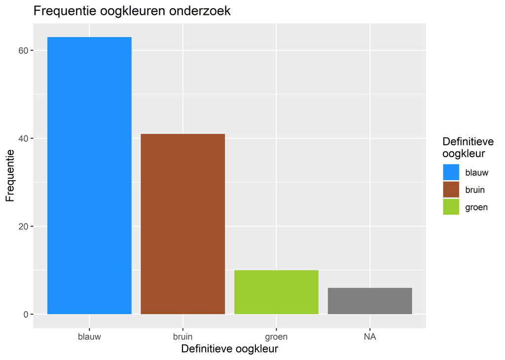

Barplot van totaal geobserveerde(frequentie) aantal per oogkleur over alle meerderheid gekozen oogkleuren.

Hier is te zien hoe blauw(52,5 %) een meerder deel van de metingen uitmaakt, gevolgd door bruin(34,16667 %) en groen(8,333333 %). Zonder de NA-waarden meegerekend komt dit neer op de verhoudingen blauw, bruin, groen (55,26%, 35,96% en 8,77%).

In het kruistabel hieronder staat data uit een ander literatuuronderzoek dat is uitgevoerd om informatie over de verdeling van de oog- en haarkleur te verzamelen over populaties en deze data als een blue print te gebruiken om de nauwkeurigheid van voorspellingen op basis van DNA te verbeteren. [@Katsara2019tc] Dit onderzoek heeft meerdere datasets (haarkleur en oogkleur per land), waaruit 3 percentages zijn gehaald voor vergelijking met dit onderzoek.

*Omdat de data uit het literatuuronderzoek in percentages zijn, zijn ook de percentages van de waarnemingen van de oogkleur uit het eigen onderzoek berekend om daarmee data met elkaar te vergeleken.*

Percentages waargenomen oogkleur literatuuronderzoek en eigen onderzoek

|  | Percentage.Blauw | Percentage.Bruin | Percentage.Groen |
| --- | --- | --- | --- |
| Literatuuronderzoek | 60.1% | 21.7% | 11.4% |
| Eigenonderzoek | 52.5% | 34.17% | 8.33% |

De `chi-squar` p-waarde tussen de percentages uit het literatuuronderzoek en eigen onderzoek is 1.837e-13 (α = .05). Om antwoord te krijgen of de Hanze aanleg heeft voor een bepaalde oogkleur zijn ook de locaties vergeleken.

## Verschil tussen locaties

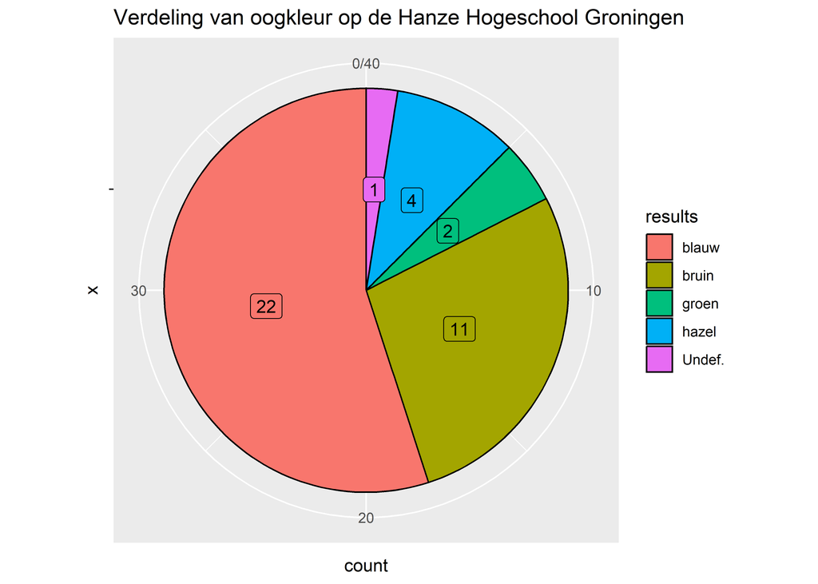

Drie taart grafieken die de tellingen tussen de oogkleuren per locatie vergelijken.

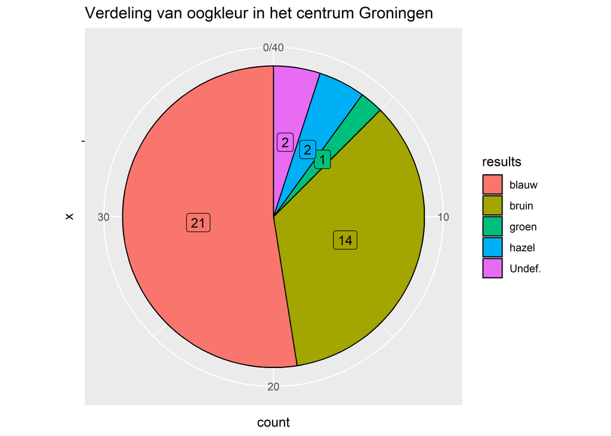

Drie taart grafieken die de tellingen tussen de oogkleuren per locatie vergelijken.

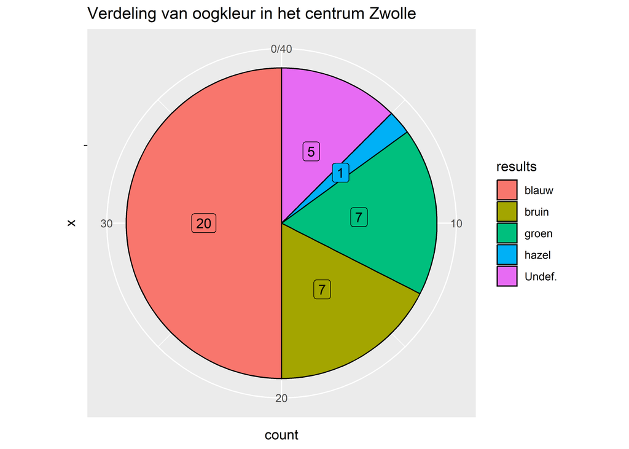

Drie taart grafieken die de tellingen tussen de oogkleuren per locatie vergelijken.

Qua locaties heeft de hanze 5-10% meer mensen met blauwe ogen dan de andere locaties, dit vergeleken met een afwijking van 9,3% van de literatuur tegenover alle blauw opnames en een gemiddelde afwijking van 24% tussen alle waardes, kunnen deze waarnemingen toeval zijn. In Zwolle zijn veel meer groene oogkleuren gevonden dan op de Hanze in Groningen.

Tenslotte zijn in Groningen naast blauw ook de meeste hazel kleurige ogen gevonden. Viermaal zoveel dan in Zwolle.

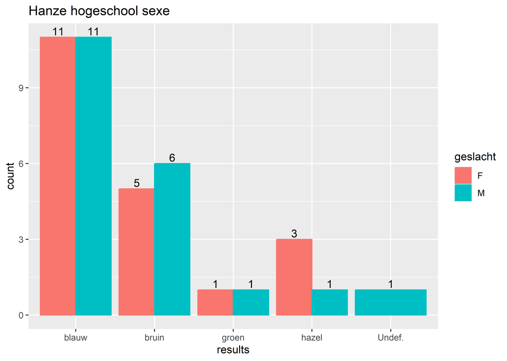

Drie barplots met aantallen per oogkleur per locatie, onder drie gemeten locaties. Verdeeld onder sexe.

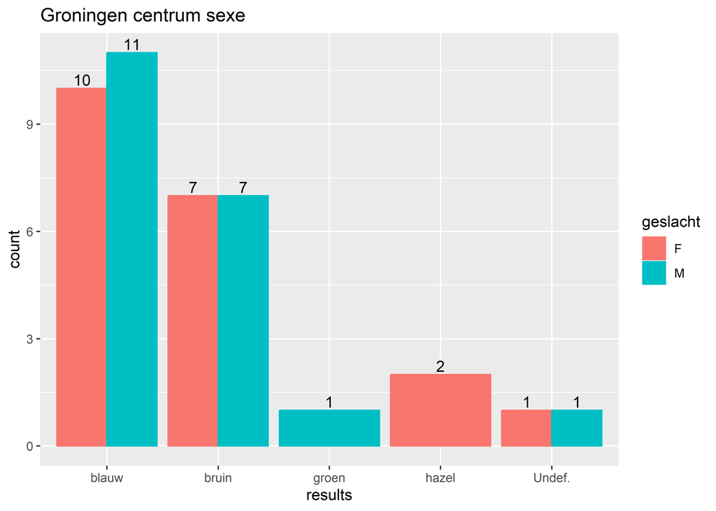

Drie barplots met aantallen per oogkleur per locatie, onder drie gemeten locaties. Verdeeld onder sexe.

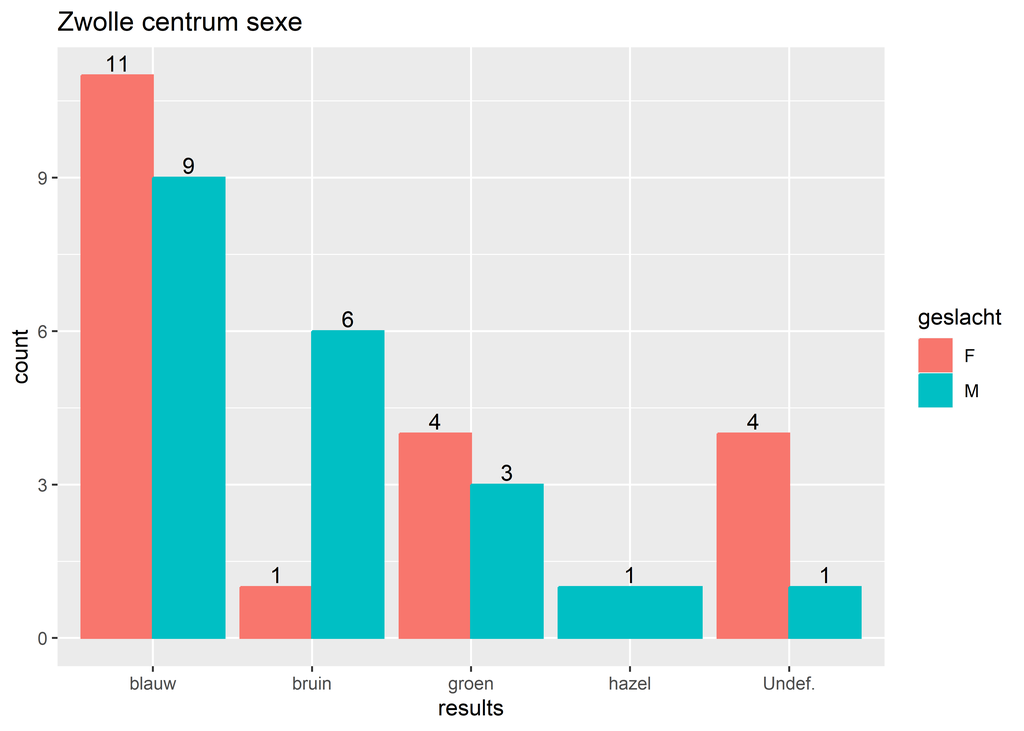

Drie barplots met aantallen per oogkleur per locatie, onder drie gemeten locaties. Verdeeld onder sexe.

Het verschil tussen verschillende locaties is geen significant verschil (p-waarde = 0.08554, α = 0,05). Het verschil tussen de bruine en blauwe oogkleur in Groningen ziet er wel significant uit.

## Verschil tussen mannen en vrouwen

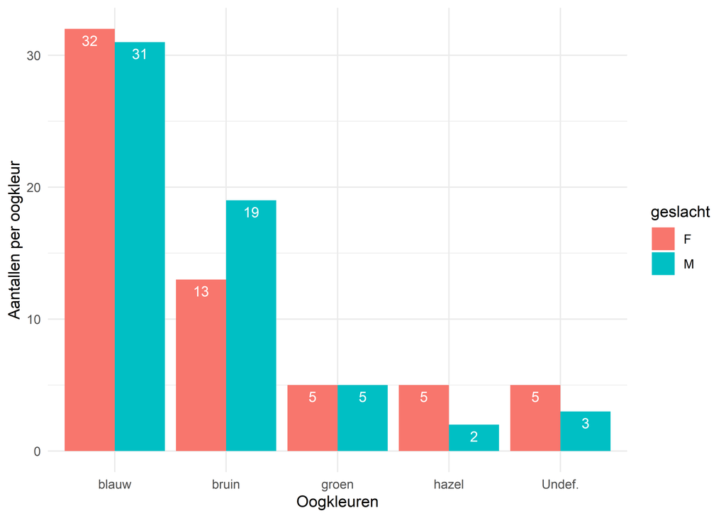

Barplot aantal oogkleuren per geslacht alle locaties samen. Verdeeld onder sexe.

# Discussie en Conclusies

**Conclusie**

**Discussie**

# Online bijlagen

**README**

- https://github.com/cheyennebrouwer/eyeresearch/blob/main/README.md

**Protocol**

- https://github.com/cheyennebrouwer/eyeresearch/blob/main/protocol/protocol_oogkleur.Rmd

**Materialen**

- Oogkleurreferentiekaart: https://github.com/cheyennebrouwer/eyeresearch/blob/main/protocol/oogkleur_refferenties.png

**Ruwe data eigen onderzoek**

- Oogkleur_simpel2: https://github.com/cheyennebrouwer/eyeresearch/blob/main/analyse/data/Oogkleur_simpel2.csv
- Oogkleur definitief (met _OK…): https://github.com/cheyennebrouwer/eyeresearch/blob/main/analyse/data/Oogkleur_simpel_definitief.csv
- Oogkleur definitief (zonder _OK…): https://github.com/cheyennebrouwer/eyeresearch/blob/main/analyse/data/Oogkleur_simpel.csv
- Oogkleur data uitgebreid: https://github.com/cheyennebrouwer/eyeresearch/blob/main/ruwe_data/Oogkleur_uitgebreid.xlsx

**Achtergrondinformatie oogkleuren**

- https://github.com/cheyennebrouwer/eyeresearch/blob/main/analyse/Achtergrondinformatie_oogkleur.Rmd

**Literatuuronderzoek**

- https://github.com/cheyennebrouwer/eyeresearch/blob/main/analyse/True_colors_A_literature_review_on_the_spatial_dis.pdf

**Logboeken**

- https://github.com/cheyennebrouwer/eyeresearch/tree/main/logs

## Notitie software

### Google Docs

Gebruikte versie: 1.23.162.05.90

Referentie: https://play.google.com/store/apps/details?id=com.google.android.apps.docs.editors.sheets&pli=1

### Apple notities

Gebruikte versie: geen data

Referentie: https://apps.apple.com/us/app/notes/id1110145109

### Keep My Notes

Gebruikte versie: 1.80.180

Referentie: https://www.keepmynotes.app/

## R

Gebruikte versie: 4.3.0

Referentie: https://www.r-project.org/

## R libraries

### plyr

Gebruikte versie: 1.8.8

Referentie: https://www.rdocumentation.org/packages/plyr/versions/1.8.8

### dplyr

Gebruikte versie: 1.1.2

Referentie: https://www.rdocumentation.org/packages/dplyr/versions/1.0.10

### **ggplot2**

Gebruikte versie: 3.4.2

Referentie: https://www.rdocumentation.org/packages/ggplot2/versions/3.4.2

### **knitr**

Gebruikte versie: 1.43

Referentie: https://www.rdocumentation.org/packages/knitr/versions/1.43

### tidyr

Gebruikte versie: 1.3.0

Referentie: https://cran.r-project.org/web/packages/tidyr/index.html

## Software Tools

### R-studio

Gebruikte versie: 2023.03.0 (Windows en MacOS versies)

Gebruiksreden: Het ontwikkelen van R code voor de analyse van de data.

Referentie: https://posit.co/products/open-source/rstudio/

# Referenties